# presentation

```r
knitr::opts_chunk$set(fig.width=15, fig.height = 12)
```

# Load data

# Get df

# Get otu_keep

# Write fasta of sequences

```r
headers = paste(">seq" , seq(1, ncol(otu)), sep = "")

#Sequences must all be the same length
seqs <- sapply(colnames(otu), function(x) return(strtrim(x, 440)))

fasta = paste(headers, seqs, sep = "\n")
write(fasta, "seqs.fasta")
```

# GetFullDF

# Linear Regression

#### Setup Linear Regression Helpers

## Regression function

```r
regression <- function(y, df, otu = NA, merc = FALSE, method ){
  other <- getOther(y)
  df_use <- select(df, -c(other))
  if(!merc){
    df_use <- select(df_use, -c(merc_vars))
  }
  if(!is.na(otu)){
    df_tmp <- cbind(df_use, otu)
    colnames(df_tmp) <- c(colnames(df_use), colnames(otu))
    df_use <- df_tmp
  }
  x <- colnames(df_use)
  x <- x[x != y]
  form <- getFormula(x, y)
  df_stand <- as.data.frame(apply(df_use, 2, function(var){
    if(range(var)[1] == 0 & range(var)[2] == 1){
      return(var)
    }
    else{
      return( (var - mean(var, na.rm = T)) / sd(var, na.rm = T))
    }
  }))

  if(method == "cvglmnet"){
    input <- df_stand[,x]
    target <- df_stand[,y]
    fit <- cv.glmnet(as.matrix(input), target,family = "gaussian")
    train_preds = predict(fit, as.matrix(input), s = fit$lambda[length(fit$lambda)])
    fit$mse = sum((train_preds - target)^2)
    print(fit$mse)
  }
  if(method == "basic"){
    fit <- lm(form, df_stand)
    fit$rval <- summary(fit)$adj.r.squared
  }
  if(method == "glmnet"){
    input <- df_stand[,x]
    target <- df_stand[,y]
    fit <- glmnet(x = as.matrix(input), target, family = "gaussian")
    num_lamb <- length(fit$lambda)
    rsquared <- fit$dev.ratio[num_lamb]
    print(rsquared)
  }

  return(fit)
}
```

## Regression Random Noise

## PlotVariationExplained

# Significant Coefficients function

# getRvalues

# Run Linear Test Glmnet

```r
runLinearTestGlmnet <- function(y, df, otu_mat, title ){
  set.seed(1)
  method = "cvglmnet"
  basic <- regression(y, df, otu = NA, merc = F, method = method)
  basic_merc <- regression(y, df, otu = NA, merc = T, method = method)
  basic_micro <- regression(y, df, otu = otu_mat, merc = F, method = method)
  basic_micro_merc = regression(y, df, otu = otu_mat, merc = T, method = method)

  random1 = regression_randomNoise(y = y, df, otu = otu_mat, num_vars = 3, method = method)

  random2 = regression_randomNoise(y = y, df, otu = otu_mat, num_vars = ncol(otu_mat), method = method)

  random3 = regression_randomNoise(y = y, df, otu = otu_mat, num_vars = ncol(otu_mat) + 3, method = method)

  plotVariationExplained(data.frame(basic = basic$mse,
                         basic_merc = basic_merc$mse,
                         basic_micro = basic_micro$mse,
                         basic_micro_merc = basic_micro_merc$mse,
                         rand1 = random1, rand2 = random2, rand3 = random3),
                         title = title, ylab = "mse")

  return(list(basic, basic_merc, basic_micro, basic_micro_merc))
}
```

# Run Linear Test Basic

```r
library(reshape2)
library(ggplot2)
library(glmnet)
runLinearTestBasic <- function(y, df, otu_mat, title ){
  set.seed(1)
  method = "basic"
  basic <- regression(y, df, otu = NA, merc = F, method = method)
  basic_merc <- regression(y, df, otu = NA, merc = T, method = method)
  basic_micro <- regression(y, df, otu = otu_mat, merc = F, method = method)
  basic_micro_merc = regression(y, df, otu = otu_mat, merc = T, method = method)

  random1 = regression_randomNoise(y = y, df, otu = otu_mat, num_vars = 3, method = method)

  random2 = regression_randomNoise(y = y, df, otu = otu_mat, num_vars = ncol(otu_mat), method = method)

  random3 = regression_randomNoise(y = y, df, otu = otu_mat, num_vars = ncol(otu_mat) + 3, method = method)

plotVariationExplained(data.frame(
                       basic = getRvalues(method, basic),
                       basic_merc = getRvalues(method, basic_merc),
                       basic_micro = getRvalues(method, basic_micro),
                       basic_micro_merc = getRvalues(method, basic_micro_merc),
                       rand1 = random1, rand1 = random2, rand3 = random3),
                       title = title, ylab = "var_exp")



  print("Basic Model: ")
  print(getSigCoefs(basic))

  print("Basic + Merc Model: ")
  print(getSigCoefs(basic_merc))

  print("Basic + Micro Model: ")
  print(getSigCoefs(basic_micro))

  print("Basic + Micro + Merc Model: ")
  print(getSigCoefs(basic_micro_merc))

}
```

# PDI linear regression

##### How much of PDI score variance can be explained by 1. just metadata 2. metadata and mercury information 3. metadata and microbiome 4. metadata and microbiome and mercury and 5. metadata and random noise variables that match the range of the microbiome and mercury data (equivalent to a null control). And what variables are most valuable in each model?

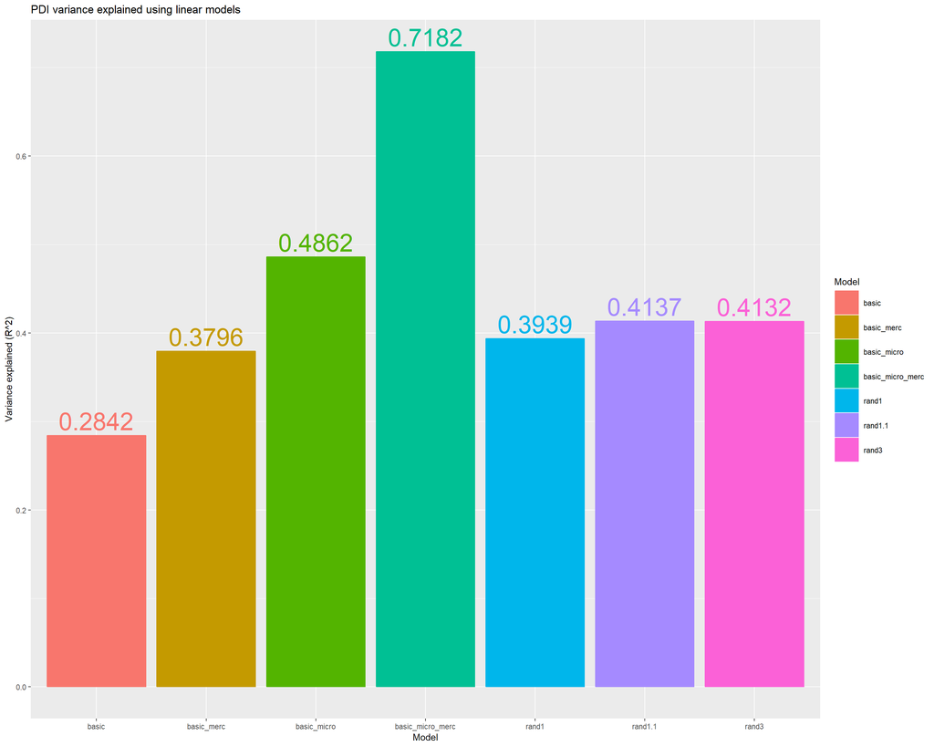

```
## [1] "Basic Model: "
##                           Estimate Std. Error   t value    Pr(>|t|)
## male_1                  -0.6115475  0.3217653 -1.900601 0.068495682
## hospital_1              -1.2904777  0.6481300 -1.991079 0.057077831
## child_fishshrimp_24hr_1  1.2698204  0.4261962  2.979427 0.006186518
## [1] "Basic + Merc Model: "
##                            Estimate Std. Error   t value    Pr(>|t|)
## male_1                   -0.7772064  0.3210421 -2.420887 0.023780175
## hospital_1               -1.7171165  0.6533106 -2.628331 0.015024150
## breastfeeding_median     -0.7314663  0.3087530 -2.369099 0.026606595
## maternal_hair_thg_median -0.7156562  0.2901254 -2.466714 0.021513212
## child_fishshrimp_24hr_1   1.2432530  0.3969147  3.132292 0.004675264
## [1] "Basic + Micro Model: "
##                           Estimate Std. Error   t value   Pr(>|t|)
## male_1                  -0.8498901  0.3626388 -2.343627 0.03714017
## upperresp_1              1.4148722  0.5948664  2.378470 0.03485977
## child_fishshrimp_24hr_1  1.0158779  0.4520788  2.247126 0.04422570
## seq7                    -0.6543029  0.3147493 -2.078806 0.05974914
## seq9                    -0.6084701  0.2210300 -2.752884 0.01750848
## [1] "Basic + Micro + Merc Model: "
##                            Estimate Std. Error   t value    Pr(>|t|)
## male_1                   -1.1379184  0.2847793 -3.995790 0.003130249
## zhuang_1                  0.9070374  0.3408568  2.661051 0.026000958
## breastfeeding_median     -0.7846698  0.3248853 -2.415221 0.038914421
## maternal_hair_thg_median -1.0139748  0.2855123 -3.551423 0.006202051
## child_fishshrimp_24hr_1   1.1781262  0.3441112  3.423678 0.007583676
## seq7                     -0.7827494  0.2375050 -3.295717 0.009293180
## seq9                     -0.4436512  0.1833578 -2.419593 0.038636403
## seq16                    -0.3950425  0.1779250 -2.220275 0.053540020
## seq64                     0.7954524  0.2131805  3.731357 0.004687635
```

# MDI linear regression

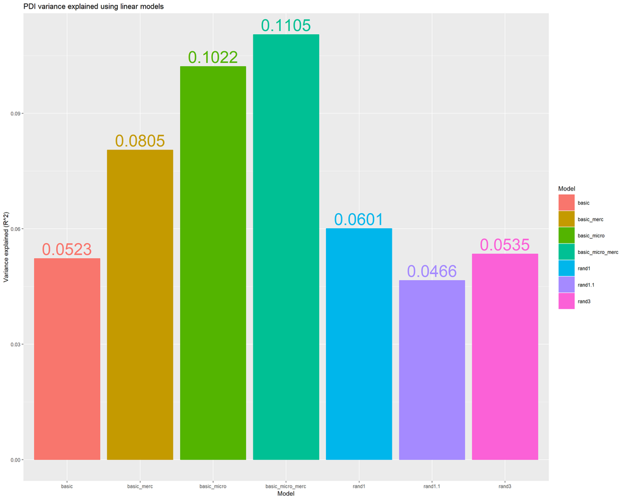

```
## [1] "Basic Model: "
##                         Estimate Std. Error  t value  Pr(>|t|)
## child_fishshrimp_24hr_1 1.062286  0.4903835 2.166236 0.0396446
## [1] "Basic + Merc Model: "
##                         Estimate Std. Error  t value   Pr(>|t|)
## child_fishshrimp_24hr_1 1.038167  0.4832199 2.148436 0.04244173
## [1] "Basic + Micro Model: "
##         Estimate Std. Error   t value   Pr(>|t|)
## seq1  -0.9728617  0.3620934 -2.686770 0.01978769
## seq21  0.8260139  0.4020172  2.054673 0.06235505
## [1] "Basic + Micro + Merc Model: "
##       Estimate Std. Error   t value   Pr(>|t|)
## seq1 -1.034978  0.3956951 -2.615594 0.02801262
```

# Interaction terms: PDI

##### We’d like to know if there are interactions between the microbes we identified and the metadata characteristics. For instance, is the influence of sequence 64 more profound if the sample also has high maternal hair mercury concentration? In this model, we don’t see any significant interactions

```
##                                    Estimate Std. Error     t value  Pr(>|t|)
## (Intercept)                     30.94361429 30.5919801  1.01149433 0.3508174
## male_1                         -21.03150178 19.8444669 -1.05981692 0.3300158
## zhuang_1                         1.95445230  1.3156708  1.48551775 0.1879511
## breastfeeding_median            -2.01800166  1.2739902 -1.58400093 0.1642841
## maternal_hair_thg_median       -31.00427184 30.5710696 -1.01417033 0.3496384
## child_fishshrimp_24hr_1        -29.42122239 30.4759391 -0.96539182 0.3716309
## hospital_1                      -3.04612954  1.9059956 -1.59818290 0.1611175
## upperresp_1                    -10.15646894 10.7742495 -0.94266138 0.3822443
## seq7                            40.08654821 43.1679704  0.92861786 0.3889182
## seq9                            -1.55272799  1.2424296 -1.24975132 0.2579285
## seq16                           -0.74990662  1.0487458 -0.71505090 0.5014401
## seq64                            1.68932604  2.4878718  0.67902455 0.5224383
## male_1:seq7                     -1.03963368  1.0924619 -0.95164299 0.3780227
## zhuang_1:seq7                    1.86344604  1.8970259  0.98229870 0.3638875
## breastfeeding_median:seq7        0.99754548  1.6463500  0.60591337 0.5667721
## maternal_hair_thg_median:seq7  -42.18517407 43.0791513 -0.97924803 0.3652752
## child_fishshrimp_24hr_1:seq7   -42.13191697 42.9423486 -0.98112745 0.3644198
## hospital_1:seq7                 -2.47270828  2.5394409 -0.97372155 0.3677998
## upperresp_1:seq7               -42.21702447 43.0904436 -0.97973056 0.3650555
## male_1:seq9                      0.38714041  0.6506835  0.59497499 0.5735983
## zhuang_1:seq9                    0.66091703  0.7566675  0.87345762 0.4159985
## breastfeeding_median:seq9       -0.11166396  0.5972578 -0.18696108 0.8578528
## maternal_hair_thg_median:seq9    0.02938712  0.5154654  0.05701086 0.9563877
## child_fishshrimp_24hr_1:seq9    -0.34246194  1.1287722 -0.30339332 0.7718351
## upperresp_1:seq9                 0.70865727  0.9371312  0.75619854 0.4781590
## male_1:seq16                    -0.16274719  0.6383408 -0.25495347 0.8072730
## zhuang_1:seq16                   0.94743623  1.1046566  0.85767489 0.4240015
## breastfeeding_median:seq16      -0.29697905  0.8041493 -0.36930836 0.7245808
## maternal_hair_thg_median:seq16  -0.31240424  0.7171044 -0.43564680 0.6783290
## child_fishshrimp_24hr_1:seq16    0.53313812  0.8787660  0.60668952 0.5662896
## upperresp_1:seq16                0.16048860  0.7252437  0.22128922 0.8322060
## male_1:seq64                   -36.08418588 37.9423774 -0.95102596 0.3783115
## zhuang_1:seq64                   0.58717404  2.8861269  0.20344707 0.8455101
## breastfeeding_median:seq64      -2.98876618  2.7615841 -1.08226515 0.3207008
## upperresp_1:seq64               37.06555992 37.9196632  0.97747598 0.3660832
```

# Interaction terms: MDI

```
##                                 Estimate Std. Error    t value   Pr(>|t|)
## (Intercept)                  -0.26731596  0.6557946 -0.4076215 0.68788185
## TreatmentGroup               -0.14953503  0.4491132 -0.3329562 0.74263229
## male_1                        0.11341784  0.3734435  0.3037081 0.76448726
## upperresp_1                   1.24753986  0.6592370  1.8923996 0.07300389
## fever_1                       0.41471386  0.5341936  0.7763362 0.44663508
## illness_1                    -1.09176765  0.7389822 -1.4773937 0.15514504
## hospital_1                   -0.86424116  0.7824912 -1.1044740 0.28249865
## mother_farmer_1               0.42621402  0.5495670  0.7755451 0.44709165
## zhuang_1                     -0.72001055  0.4796707 -1.5010517 0.14896541
## mother_hs_univ                0.23403340  0.2361505  0.9910352 0.33350777
## breastfeeding_median          0.13836317  0.3625152  0.3816755 0.70672699
## maternal_hair_thg_median     -0.33252035  0.3500358 -0.9499609 0.35347130
## child_hair_thg_median         0.89226621  0.4506617  1.9799023 0.06164183
## child_fishshrimp_24hr_1       0.77654237  0.6301075  1.2323966 0.23209286
## child_tofusoymilk_24hr_1      0.23142288  0.5067826  0.4566512 0.65284244
## child_cowsmilk_24hr_1         0.53455016  0.4804445  1.1126157 0.27906850
## child_egg_24hr_1              0.09861174  0.7372691  0.1337527 0.89493486
## child_hair_thg               -0.21946235  0.2103423 -1.0433583 0.30923052
## seq1                         -0.34355380  0.2004175 -1.7141907 0.10195050
## seq21                         0.39751301  0.2272199  1.7494640 0.09554095
## child_fishshrimp_24hr_1:seq1  0.08233465  0.7726357  0.1065633 0.91619706
```

```
##
##  Pearson's product-moment correlation
##
## data:  as.numeric(otu_keep[, "seq1"]) and df$child_fishshrimp_24hr_1
## t = -1.7122, df = 39, p-value = 0.0948
## alternative hypothesis: true correlation is not equal to 0
## 95 percent confidence interval:
##  -0.52902893  0.04706576
## sample estimates:
##        cor
## -0.2644133
```

```
##
##  Pearson's product-moment correlation
##
## data:  as.numeric(otu_keep[, "seq21"]) and df$child_fishshrimp_24hr_1
## t = -0.37571, df = 39, p-value = 0.7092
## alternative hypothesis: true correlation is not equal to 0
## 95 percent confidence interval:
##  -0.3610339  0.2522573
## sample estimates:
##         cor
## -0.06005378
```

```
## [1] "seq1:  Bacteria_Firmicutes_Clostridia_Clostridiales_Ruminococcaceae_Faecalibacterium"
```

# PERMANOVA

##### Asking the reverse question - how much of the microbiomes structure differences can be explained by each lifestyle characteristic. Note we’re using just the top 14 most abundant otus (present in > 25% of samples). Having a farmer mother can explain 6% of the variance and being a male can explain 4.5%.

```
## Permutation test for adonis under reduced model
## Terms added sequentially (first to last)
## Permutation: free
## Number of permutations: 9999
##
## adonis2(formula = form, data = as.data.frame(df), permutations = 9999, method = "bray")
##                          Df SumOfSqs      R2      F Pr(>F)
## TreatmentGroup            1   0.0817 0.00724 0.2555 0.9003
## male_1                    1   0.5122 0.04540 1.6016 0.1812
## upperresp_1               1   0.2217 0.01965 0.6931 0.6255
## fever_1                   1   0.0780 0.00691 0.2438 0.9050
## illness_1                 1   0.3108 0.02755 0.9718 0.4484
## hospital_1                1   0.1623 0.01438 0.5073 0.7621
## mother_farmer_1           1   0.7180 0.06363 2.2448 0.0645 .
## zhuang_1                  1   0.0342 0.00303 0.1068 0.9541
## mother_hs_univ            1   0.2351 0.02083 0.7349 0.6052
## breastfeeding_median      1   0.0596 0.00528 0.1863 0.9301
## maternal_hair_thg_median  1   0.1931 0.01711 0.6038 0.6795
## child_hair_thg_median     1   0.3715 0.03292 1.1614 0.3512
## child_fishshrimp_24hr_1   1   0.1173 0.01039 0.3666 0.8398
## child_tofusoymilk_24hr_1  1   0.2078 0.01842 0.6499 0.6562
## child_cowsmilk_24hr_1     1   0.1994 0.01767 0.6234 0.6771
## child_egg_24hr_1          1   0.0947 0.00839 0.2960 0.8776
## child_hair_thg            1   0.1069 0.00948 0.3343 0.8620
## bayley36_mdi_adj          1   0.5524 0.04895 1.7271 0.1438
## bayley36_pdi_adj          1   0.3104 0.02751 0.9704 0.4444
## Residual                 21   6.7165 0.59526
## Total                    40  11.2832 1.00000
## ---
## Signif. codes:  0 '***' 0.001 '**' 0.01 '*' 0.05 '.' 0.1 ' ' 1
```

##### Now the same test but using all otus instead of the top 14

```r
dist_bray <- vegdist(otu[rownames(df), ], method = "bray")
vars <- paste(colnames(df), collapse = "+")
form <-  formula(paste("dist_bray ~", vars))
perm = adonis2(form, data = as.data.frame(df), method = "bray", perm = 9999)
perm
```

```
## Permutation test for adonis under reduced model
## Terms added sequentially (first to last)
## Permutation: free
## Number of permutations: 9999
##
## adonis2(formula = form, data = as.data.frame(df), permutations = 9999, method = "bray")
##                          Df SumOfSqs      R2      F Pr(>F)
## TreatmentGroup            1   0.4365 0.02441 0.9660 0.6320
## male_1                    1   0.4690 0.02622 1.0379 0.3227
## upperresp_1               1   0.4211 0.02355 0.9319 0.7726
## fever_1                   1   0.4881 0.02729 1.0801 0.1787
## illness_1                 1   0.4251 0.02377 0.9407 0.7455
## hospital_1                1   0.3842 0.02148 0.8502 0.9683
## mother_farmer_1           1   0.4791 0.02679 1.0602 0.2367
## zhuang_1                  1   0.3854 0.02155 0.8529 0.9631
## mother_hs_univ            1   0.4820 0.02695 1.0667 0.2158
## breastfeeding_median      1   0.4478 0.02504 0.9909 0.5258
## maternal_hair_thg_median  1   0.4882 0.02730 1.0804 0.1751
## child_hair_thg_median     1   0.4429 0.02476 0.9801 0.5706
## child_fishshrimp_24hr_1   1   0.4204 0.02350 0.9303 0.7880
## child_tofusoymilk_24hr_1  1   0.4635 0.02591 1.0256 0.3667
## child_cowsmilk_24hr_1     1   0.4813 0.02691 1.0651 0.2225
## child_egg_24hr_1          1   0.3858 0.02157 0.8537 0.9639
## child_hair_thg            1   0.4147 0.02318 0.9176 0.8473
## bayley36_mdi_adj          1   0.4295 0.02402 0.9505 0.7041
## bayley36_pdi_adj          1   0.4506 0.02519 0.9971 0.4871
## Residual                 21   9.4897 0.53060
## Total                    40  17.8850 1.00000
```

# Phylogenetic tree

##### Of the taxa that were labeled as “valuable” in the above models (seq7, seq9, seq16, seq64), the first three were associated with lower pdi and the last was associated with higher. We’d like to see where they fall on the phylogenetic tree. Red means negatively associated with pdi, and green means positively associated

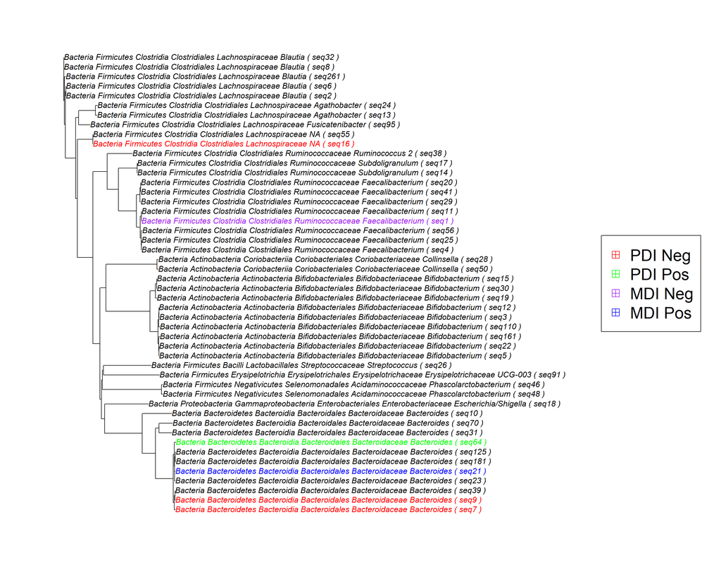

```r
ps <- readRDS("data/ps.RDS")
taxa_names(ps) <- dict_esv_seq$seq
phy_tree(ps) <- tree

ps_filt <- filter_taxa(ps, function(abund) return(sum(abund > 0) > 8), prune = T)
seqs <- taxa_names(ps_filt)

rownames(dict_esv_seq) <- dict_esv_seq$seq
taxa <- dict_esv_seq[seqs, ]$taxa
taxa <- paste(taxa, "(", seqs, ")")

#Plot automatic colors
cols = rep("black", length(taxa))

for (seq in seqvars_pdi_neg){
  cols[grepl(seq, taxa)] <- "red"
}
for(seq in seqvars_pdi_pos){
  cols[grepl(seq, taxa)] <- "green"
}
for(seq in seqvars_mdi_neg){
  cols[grepl(seq, taxa)] <- "purple"
}
for(seq in seqvars_mdi_pos){
  cols[grepl(seq, taxa)] <- "blue"
}

tree <- phy_tree(ps_filt)
tree$tip.label <- taxa
plot(tree, tip.color = cols, cex = 1)
legend("right", legend = c("PDI Neg", "PDI Pos", "MDI Neg", "MDI Pos"), col = c("red", "green", "purple", "blue"), pch = 12, cex= 2 )
```

```r
#plot_tree(ps_filt, label.tips = "taxa_names", tip.colors = 'red')
```

# Boxplots

##### lastly, we’d like to directly see how the abunance of the microbial taxa relates to the pdi.

```
## [1] "seq7"
```

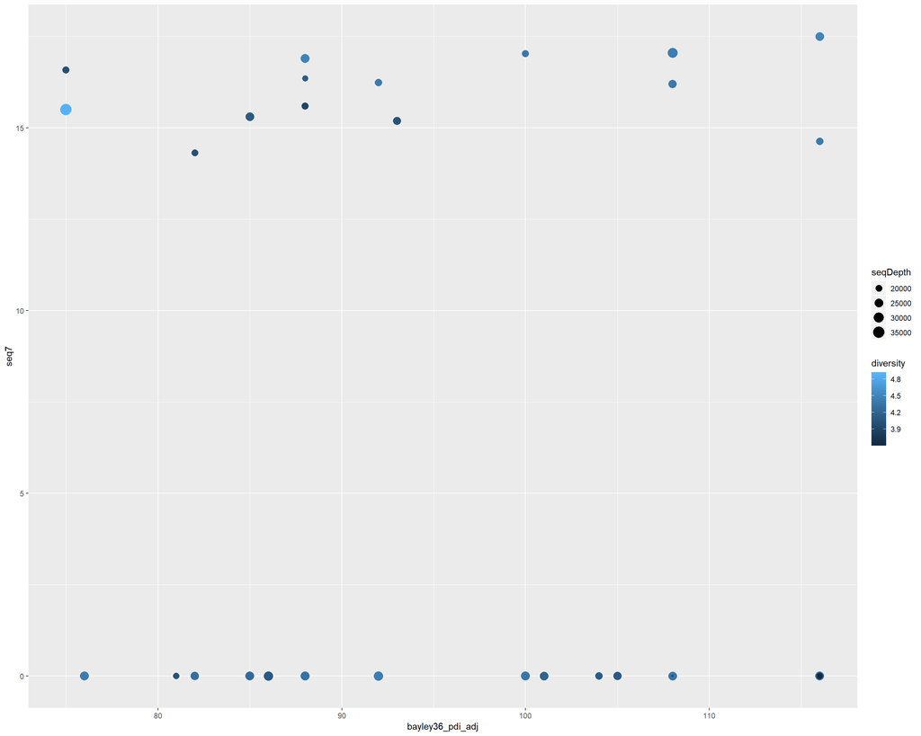

```
## [1] "seq9"
```

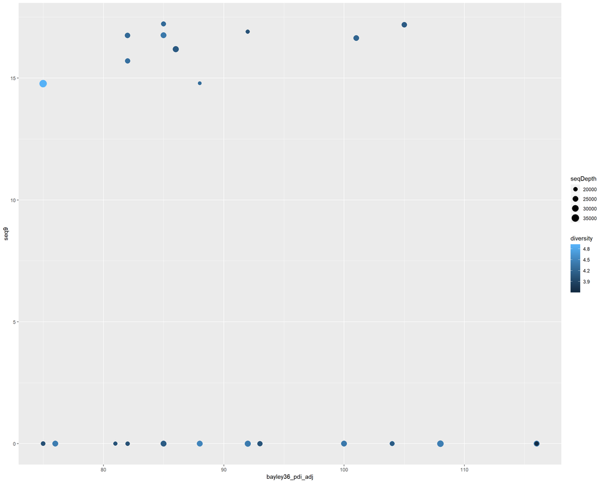

```
## [1] "seq16"
```

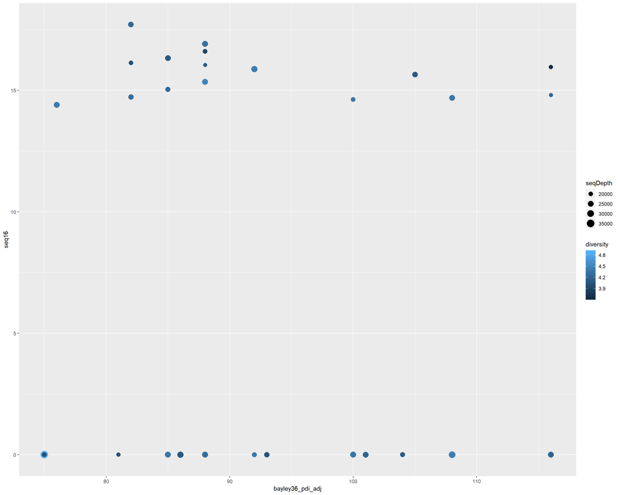

```
## [1] "seq64"
```

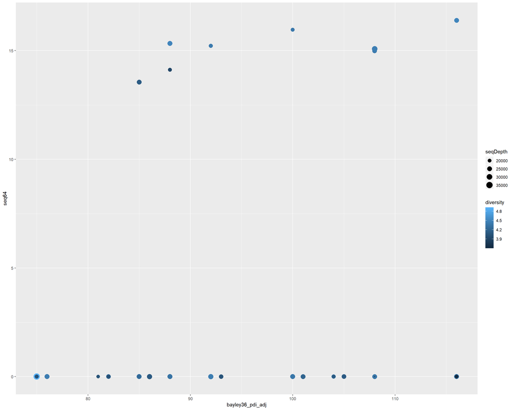

```
## [1] "seq1"
```

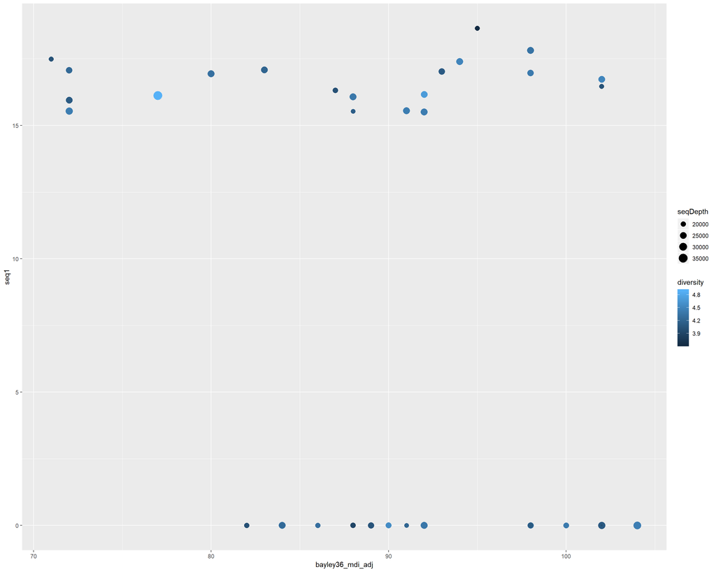

```
## [1] "seq21"
```

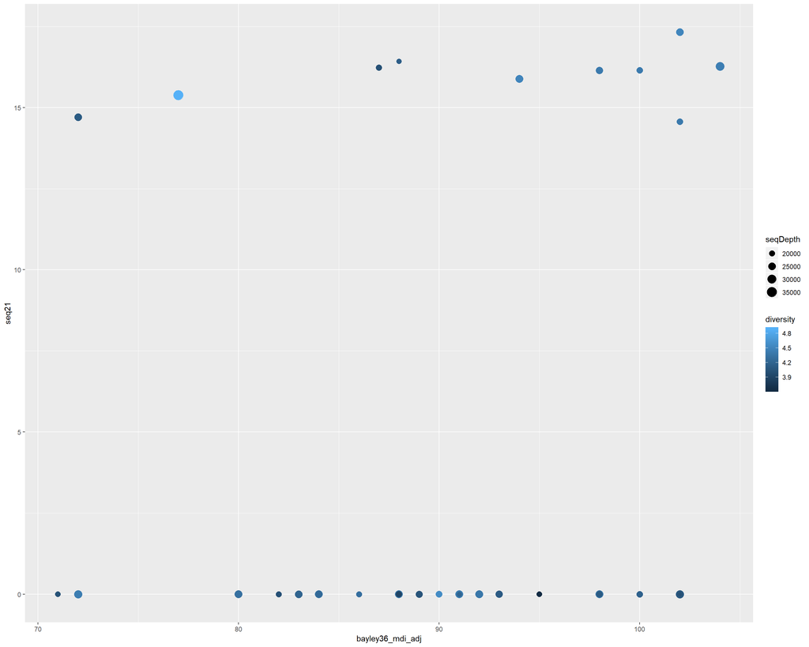

# Alpha diversity and MDI

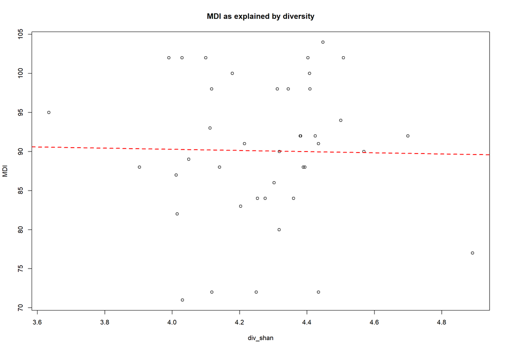

```r
div_shan = vegan::diversity(otu_raw, index = "shannon")
num_species = apply(otu_dds, 1, function(sample) return(sum(sample > 0)))
div_simp = vegan::diversity(otu_raw, index = "simpson")

df_div = df
df_div$div_shan = div_shan
df_div$div_simp = div_simp
df_div$num_species = num_species

plotCorrelation <- function(div = "div_shan", target = "mdi"){
  if(target == "mdi"){
      mod <- lm(df_div$bayley36_mdi_adj ~ df_div[[div]] )
      plot(df_div[[div]], df_div$bayley36_mdi_adj, ylab = "MDI", xlab = div, main = "MDI as explained by diversity")
      abline(coefficients(mod), lwd = 2, lty =2, col = "red")
  }
  if(target == "pdi"){
      mod <- lm(df_div$bayley36_pdi_adj ~ df_div[[div]] )
      plot(df_div[[div]], df_div$bayley36_pdi_adj, ylab = "PDI", xlab = div, main = "PDI as explained by diversity")
      abline(coefficients(mod), lwd = 2, lty =2, col = "red")

  }
}

plotCorrelation(div = "div_shan", target = "mdi")
```

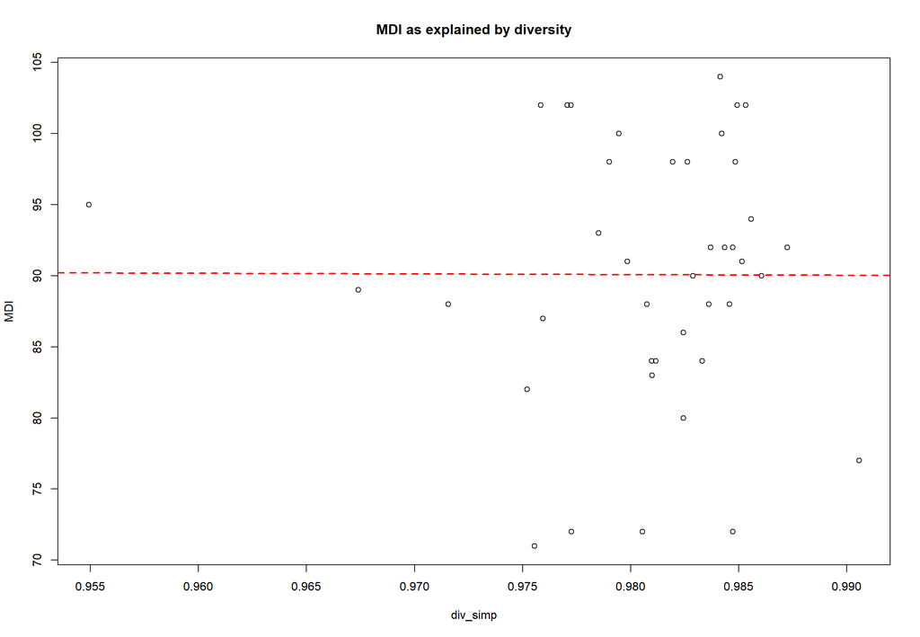

```r
plotCorrelation(div = "div_simp", target = "mdi")
```

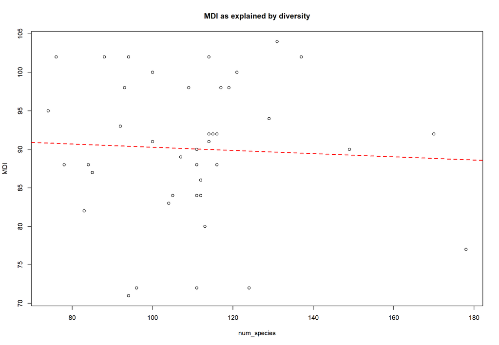

```r
plotCorrelation(div = "num_species", target = "mdi")
```

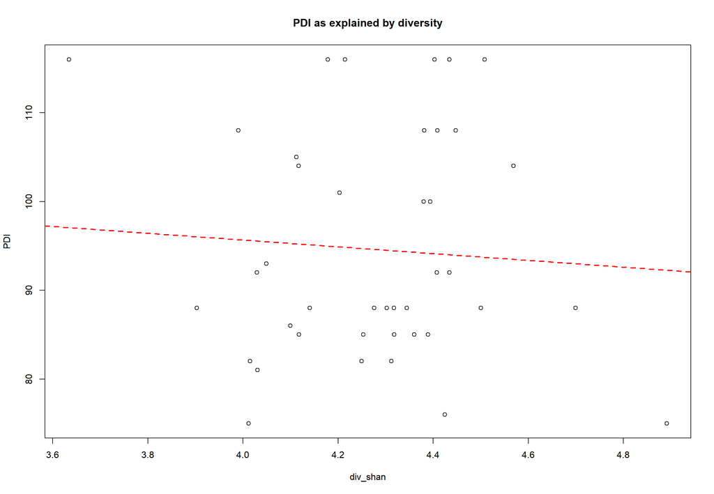

```r
plotCorrelation(div = "div_shan", target = "pdi")
```

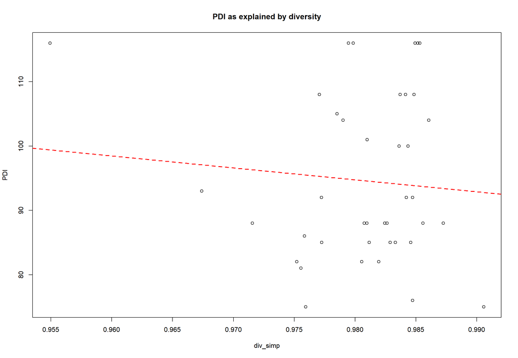

```r
plotCorrelation(div = "div_simp", target = "pdi")
```

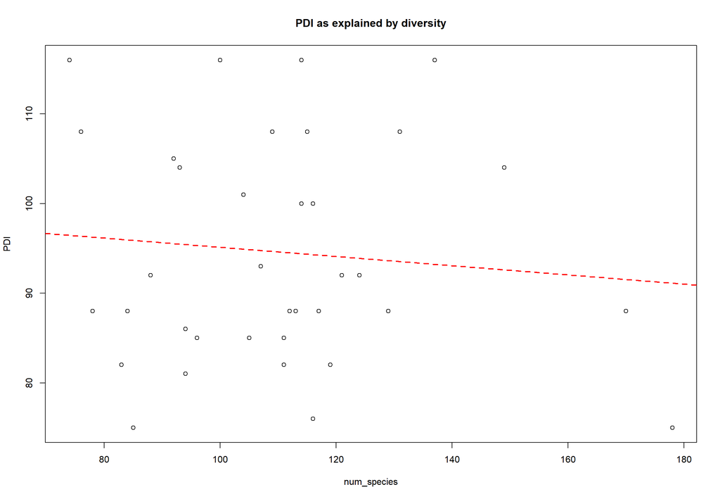

```r
plotCorrelation(div = "num_species", target = "pdi")
```

```r
cor.test(div_shan, df_div$bayley36_mdi_adj)
```

```
##
##  Pearson's product-moment correlation
##
## data:  div_shan and df_div$bayley36_mdi_adj
## t = -0.11759, df = 39, p-value = 0.907
## alternative hypothesis: true correlation is not equal to 0
## 95 percent confidence interval:
##  -0.3245965  0.2905069
## sample estimates:
##         cor
## -0.01882611
```

```r
cor.test(num_species, df_div$bayley36_mdi_adj)
```

```
##
##  Pearson's product-moment correlation
##
## data:  num_species and df_div$bayley36_mdi_adj
## t = -0.31475, df = 39, p-value = 0.7546
## alternative hypothesis: true correlation is not equal to 0
## 95 percent confidence interval:
##  -0.3525276  0.2613615
## sample estimates:
##         cor
## -0.05033642
```

```r
cor.test(div_simp, df_div$bayley36_mdi_adj)
```

```
##
##  Pearson's product-moment correlation
##
## data:  div_simp and df_div$bayley36_mdi_adj
## t = -0.02115, df = 39, p-value = 0.9832
## alternative hypothesis: true correlation is not equal to 0
## 95 percent confidence interval:
##  -0.3107134  0.3045811
## sample estimates:
##          cor
## -0.003386705
```

# Correlation between all 14 microbes

```r
library(corrplot)
res <- cor(otu_keep)
round(res, 3)
```

```
##         seq1   seq2   seq3   seq4   seq5   seq7   seq8   seq9  seq15  seq16  seq19  seq21  seq56
## seq1   1.000 -0.099  0.363  0.708  0.476  0.023 -0.147  0.137  0.084  0.145  0.258  0.237  0.648
## seq2  -0.099  1.000 -0.160 -0.191 -0.075  0.017  0.647 -0.055 -0.078  0.192  0.172 -0.099  0.010
## seq3   0.363 -0.160  1.000  0.306  0.721 -0.069 -0.209 -0.084  0.194  0.061  0.163  0.022  0.214
## seq4   0.708 -0.191  0.306  1.000  0.357 -0.154 -0.220  0.216  0.024  0.004  0.149 -0.016  0.540
## seq5   0.476 -0.075  0.721  0.357  1.000 -0.112 -0.079 -0.075  0.140  0.224  0.187  0.039  0.238
## seq7   0.023  0.017 -0.069 -0.154 -0.112  1.000  0.127 -0.303 -0.436  0.057 -0.350  0.803  0.031
## seq8  -0.147  0.647 -0.209 -0.220 -0.079  0.127  1.000 -0.007 -0.277  0.003  0.052  0.062 -0.159
## seq9   0.137 -0.055 -0.084  0.216 -0.075 -0.303 -0.007  1.000  0.186  0.027  0.153 -0.206  0.148
## seq15  0.084 -0.078  0.194  0.024  0.140 -0.436 -0.277  0.186  1.000  0.199  0.641 -0.317  0.133
## seq16  0.145  0.192  0.061  0.004  0.224  0.057  0.003  0.027  0.199  1.000  0.155 -0.105  0.012
## seq19  0.258  0.172  0.163  0.149  0.187 -0.350  0.052  0.153  0.641  0.155  1.000 -0.248  0.358
## seq21  0.237 -0.099  0.022 -0.016  0.039  0.803  0.062 -0.206 -0.317 -0.105 -0.248  1.000  0.165
## seq56  0.648  0.010  0.214  0.540  0.238  0.031 -0.159  0.148  0.133  0.012  0.358  0.165  1.000
## seq64  0.069 -0.152 -0.041 -0.092  0.081  0.766 -0.010 -0.300 -0.282  0.172 -0.217  0.674  0.091
##        seq64
## seq1   0.069
## seq2  -0.152
## seq3  -0.041
## seq4  -0.092
## seq5   0.081
## seq7   0.766
## seq8  -0.010
## seq9  -0.300
## seq15 -0.282
## seq16  0.172
## seq19 -0.217
## seq21  0.674
## seq56  0.091
## seq64  1.000
```

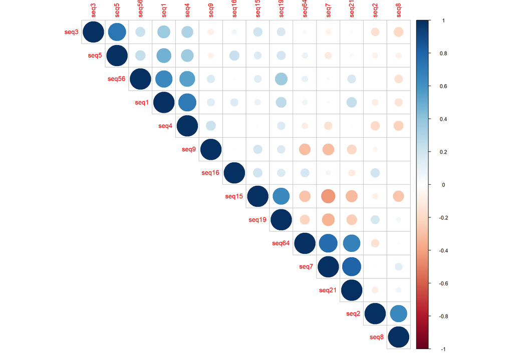

```r
corrplot(res, type = "upper", order = "hclust")
```

# Scale of mdi and pdi

##### The values appear on roughly the same scale, and are lightly correlated

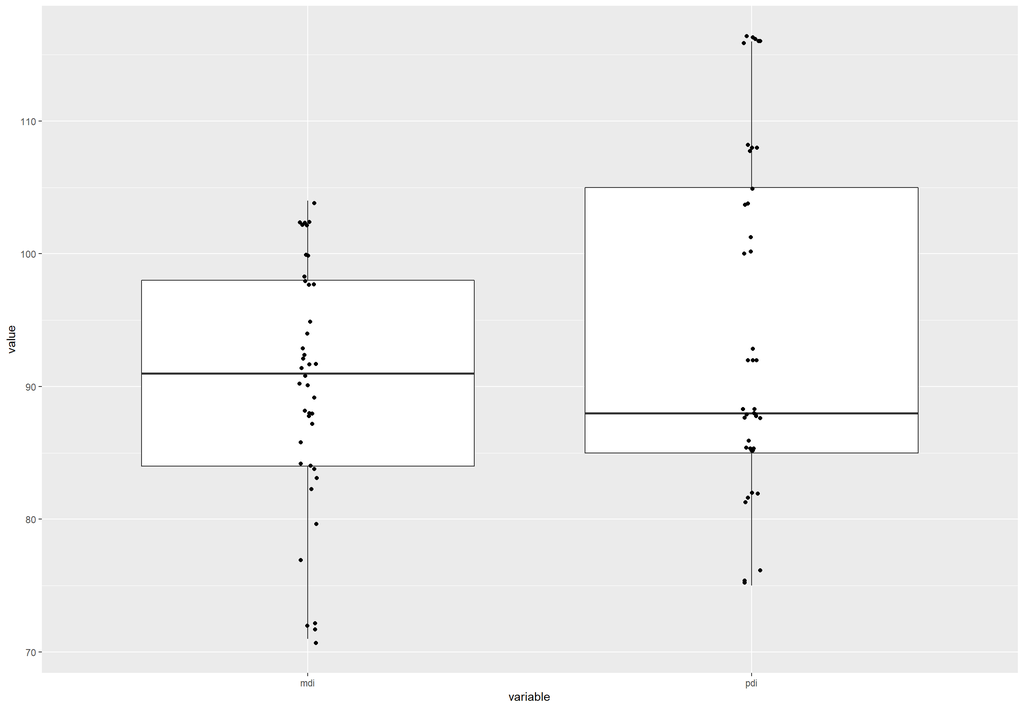

```r
tmp = data.frame(mdi = df$bayley36_mdi_adj, pdi = df$bayley36_pdi_adj)
ggplot(melt(tmp)) + geom_boxplot(aes(x = variable, y= value)) + geom_jitter(aes(x = variable, y = value), width = 0.02)
```

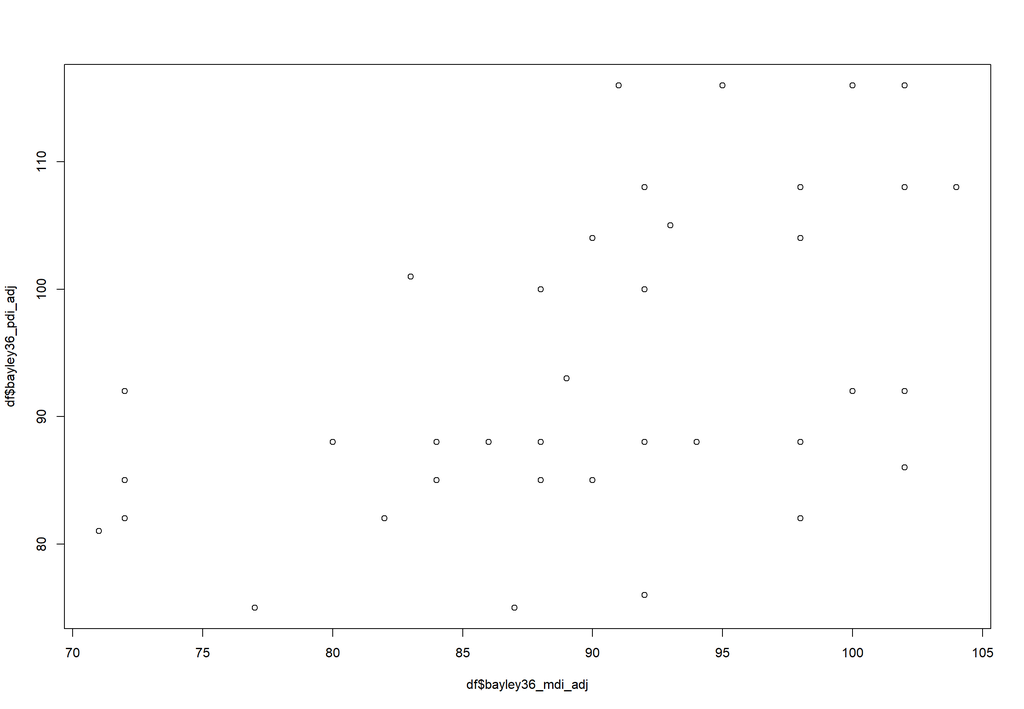

```r
plot(df$bayley36_mdi_adj, df$bayley36_pdi_adj)
```

# Are maternal and child hair Hg corrrelated?

##### Not really

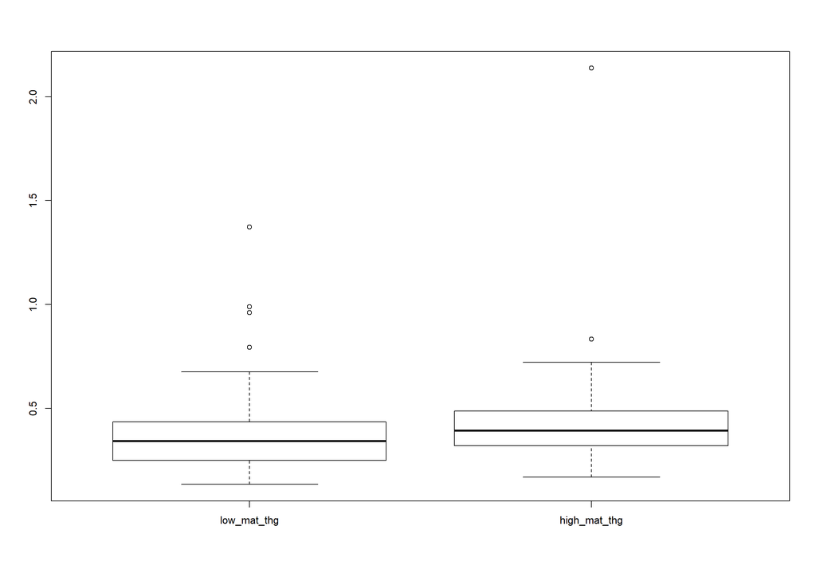

```r
low_mat_thg = df$child_hair_thg[df$maternal_hair_thg_median == 0]
high_mat_thg = df$child_hair_thg[df$maternal_hair_thg_median == 1]
boxplot(low_mat_thg, high_mat_thg, names = c("low_mat_thg", "high_mat_thg"))
```

# Cluster based on co-occurrence:

### PDI

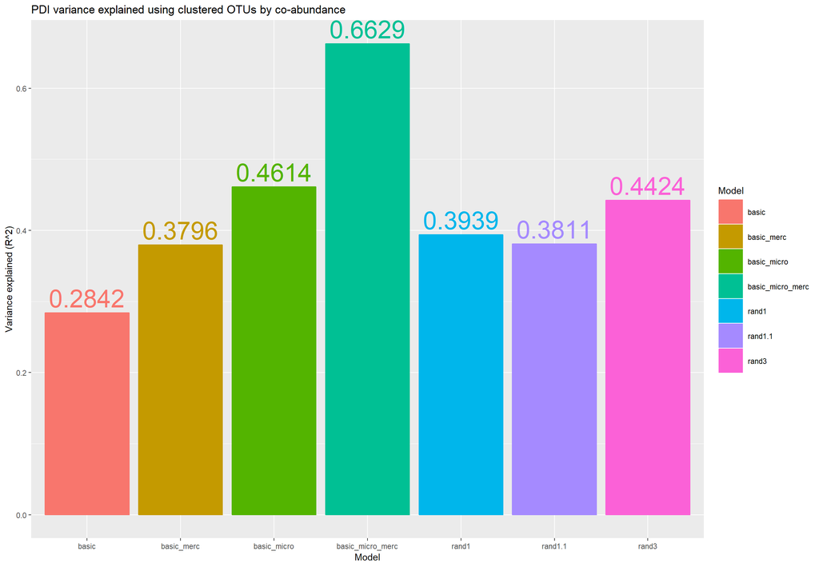

```
## [1] "Basic Model: "
##                           Estimate Std. Error   t value    Pr(>|t|)
## male_1                  -0.6115475  0.3217653 -1.900601 0.068495682
## hospital_1              -1.2904777  0.6481300 -1.991079 0.057077831
## child_fishshrimp_24hr_1  1.2698204  0.4261962  2.979427 0.006186518
## [1] "Basic + Merc Model: "
##                            Estimate Std. Error   t value    Pr(>|t|)
## male_1                   -0.7772064  0.3210421 -2.420887 0.023780175
## hospital_1               -1.7171165  0.6533106 -2.628331 0.015024150
## breastfeeding_median     -0.7314663  0.3087530 -2.369099 0.026606595
## maternal_hair_thg_median -0.7156562  0.2901254 -2.466714 0.021513212
## child_fishshrimp_24hr_1   1.2432530  0.3969147  3.132292 0.004675264
## [1] "Basic + Micro Model: "
##             Estimate Std. Error   t value   Pr(>|t|)
## male_1    -0.7781157  0.3440462 -2.261661 0.04496087
## cluster4  -0.4196564  0.1793980 -2.339248 0.03922429
## cluster11  0.4322214  0.1931640  2.237588 0.04689902
## cluster12  0.4199313  0.1913628  2.194425 0.05057610
## [1] "Basic + Micro + Merc Model: "
##                  Estimate Std. Error   t value    Pr(>|t|)
## male_1         -1.2202550  0.3099337 -3.937148 0.004313137
## child_hair_thg -0.5725527  0.2191574 -2.612518 0.031008745
## cluster1       -0.5026678  0.2029034 -2.477375 0.038267938
## cluster4       -0.4093394  0.1631116 -2.509566 0.036395533
## cluster11       0.3796409  0.1556491  2.439082 0.040622623
```

```r
knitr::opts_chunk$set(fig.width=15, fig.height = 13)
library(stats)
set.seed(1)

otu <- t(otu_table(ps_dds))
otu <- otu[ , colSums(otu)> 0]
otu <- otu[rownames(df), ]

clustered = kmeans(t(otu), centers = 15, iter.max = 50)
aggregated = lapply(unique(clustered$cluster), function(cluster) return(rowSums(otu[ , cluster])))
otu_cooccur_clust = matrix(unlist(aggregated), ncol = length(aggregated), byrow = T)
otu_cooccur_clust = otu_cooccur_clust[ , colSums(otu_cooccur_clust) > 0]
colnames(otu_cooccur_clust) <- paste("cluster", 1:ncol(otu_cooccur_clust), sep = "")

runLinearTestBasic(y = "bayley36_pdi_adj", df,
                               otu_mat = otu_cooccur_clust,
                               title =  "PDI variance explained using clustered OTUs by co-abundance")
```

### MDI

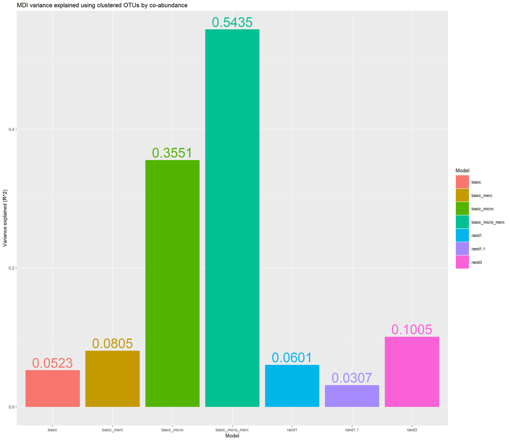

```
## [1] "Basic Model: "
##                         Estimate Std. Error  t value  Pr(>|t|)
## child_fishshrimp_24hr_1 1.062286  0.4903835 2.166236 0.0396446
## [1] "Basic + Merc Model: "
##                         Estimate Std. Error  t value   Pr(>|t|)
## child_fishshrimp_24hr_1 1.038167  0.4832199 2.148436 0.04244173
## [1] "Basic + Micro Model: "
##                  Estimate Std. Error   t value   Pr(>|t|)
## TreatmentGroup  0.9491478  0.4512293  2.103471 0.05546198
## mother_hs_univ  0.6575679  0.2495961  2.634528 0.02060928
## cluster10      -0.8227722  0.3071767 -2.678498 0.01895503
## cluster13      -0.5094755  0.2283095 -2.231512 0.04387857
## [1] "Basic + Micro + Merc Model: "
##                            Estimate Std. Error   t value    Pr(>|t|)
## TreatmentGroup            0.8965806  0.3833797  2.338623 0.041436700
## mother_hs_univ            0.4653192  0.2267675  2.051965 0.067286552
## maternal_hair_thg_median -0.6106218  0.2856717 -2.137495 0.058280569
## child_hair_thg_median     1.1102632  0.4993756  2.223303 0.050411573
## child_fishshrimp_24hr_1   1.9710171  0.7576304  2.601555 0.026420911
## cluster3                  0.3462909  0.1606869  2.155066 0.056578752
## cluster10                -0.8412242  0.2607648 -3.225989 0.009082478
## cluster13                -0.4889207  0.2163016 -2.260365 0.047339113
```

```r
set.seed(1)
clustered = kmeans(t(otu), centers = 13, iter.max = 50)
aggregated = lapply(unique(clustered$cluster), function(cluster) return(rowSums(otu[ , cluster])))
otu_cooccur_clust = matrix(unlist(aggregated), ncol = length(aggregated), byrow = T)
otu_cooccur_clust = otu_cooccur_clust[ , colSums(otu_cooccur_clust) > 0]
colnames(otu_cooccur_clust) <- paste("cluster", 1:ncol(otu_cooccur_clust), sep = "")

runLinearTestBasic(y = "bayley36_mdi_adj", df,
                               otu_mat = otu_cooccur_clust,
                               title =  "MDI variance explained using clustered OTUs by co-abundance")
```

# Cluster based on co-occurrence using glmnet for feature selection

## IMPORTANT: We are switching models and now areusing mean squared error. A LOW number means good prediction.

### PDI

```r
library(stats)
library(glmnet)
set.seed(1)
otu <- t(otu_table(ps_dds))
otu <- otu[ , colSums(otu)> 0]
otu <- otu[rownames(df), ]

#15 clusters give beautiful results
#sweet spot is between 14-15
clustered = kmeans(t(otu), centers = 15, iter.max = 50)
aggregated = lapply(unique(clustered$cluster), function(cluster) return(rowSums(otu[ , cluster])))
otu_cooccur_clust = matrix(unlist(aggregated), ncol = length(aggregated), byrow = T)
otu_cooccur_clust = otu_cooccur_clust[ , colSums(otu_cooccur_clust) > 0]
colnames(otu_cooccur_clust) <- paste("cluster", 1:ncol(otu_cooccur_clust), sep = "")



models = runLinearTestGlmnet(y = "bayley36_pdi_adj", df = df, otu_mat = otu_cooccur_clust, title = "PDI Mean Squared Error using clustered OTUs by coabundance cross validated feature selection")
```

[figure not shown]

```r
#basic <- models[[1]]
#basic_merc <- models[[2]]
#basic_micro <- models[[3]]
#basic_micro_merc <- models[[4]]
```